# Classification_Dataset1

<a id= 'top'></a>

## Model selection on dataset1:

This data set contains:

- Audio recording tags
- Recording length
- Mfcc 1 to 4
  - Max
  - Min
  - Median
  - Mean
  - Variance
- Polarity of the conversation
- Subjectivity of the conversation

All of the data was then normalized to make the model section a fair game between the tree and non tree base algorithms. Without normalization process Logistic Regression and K-Neighbors Classifier will not be able to make any accurate prediction.

At then end we have 406 predictors.

1. Reading the dataset
2. Normalizing
3. Converting recording tags to dummy variables
4. Makeing dataset
5. Model selection
   - Random Forest Classifier
   - Gradient Boosting Classifier
   - Logistic Regression
   - K-nearest neighbors
6. Feature importance

```python
from utilities import *
```

<a id= '1'></a>

## Reading the dataset:

Return to top

```python
df1 = pd.read_hdf('dataset1_tags_texts.hdf')
df1.head()
```

|  | Unnamed: 0 | category | composer_id | csat_score | gradable_id | length_audio | length_mfcc | mfcc_feat_max_1 | mfcc_feat_max_2 | mfcc_feat_max_3 | ... | mfcc_feat_var_4 | qa_score | tags | time | text | polarity | subjectivity | clean_tag | clean_text | text_lenght |
| --- | --- | --- | --- | --- | --- | --- | --- | --- | --- | --- | --- | --- | --- | --- | --- | --- | --- | --- | --- | --- | --- |
| 0 | 0 | 0 | ee04ea55145d7c4f109f5186 | good | 418139 | 411.0 | 23644 | 22.986164 | 43.494107 | 6.506795 | ... | 212.163095 | 38 | ["shipping", "tracking_inquiry__processing"] | 2017-03-13T15:43:02 | ['(0.9353249073028564): hi thank you for calli... | 0.318571 | 0.500516 | shipping tracking inquiry processing | hi thank you for calling fabfitfun meetings le... | 1345 |
| 1 | 1 | 1 | 4d469859040b84d869068942 | Novalue | 1433069 | 243.0 | 19205 | 23.589884 | 41.824955 | 8.539326 | ... | 210.699407 | 93 | ["order__shipped__order_status"] | 2017-05-08T14:51:16 | ['(0.7501416802406311): thanks again he resear... | 0.262808 | 0.417980 | order shipped order status | thanks again he researches chelsea how may hel... | 1875 |
| 2 | 2 | 1 | 9f6aff620082032a2dc319ef | offered | 18834 | 228.0 | 9283 | 22.994801 | 44.926718 | 6.764303 | ... | 191.671796 | 100 | ["application", "application_status", "non_sta... | 2017-05-11T14:21:27 | ['(0.9273091554641724): thank you for calling ... | 0.234722 | 0.375000 | application application status non state employee | thank you for calling the state of tennessee d... | 828 |
| 3 | 3 | 0 | 4d469859040b84d869068942 | Novalue | 1498618 | 234.0 | 9781 | 23.161479 | 42.192977 | 8.860758 | ... | 145.302891 | 84 | ["shave_plans__cancel_plan__overstocked"] | 2017-06-20T20:34:38 | ["(0.9570504426956177): thank you for calling ... | 0.345833 | 0.462500 | shave plans cancel plan overstocked | thank you for calling harry s my name is kayle... | 736 |
| 4 | 4 | 0 | 4d469859040b84d869068942 | Novalue | 1446730 | 334.0 | 17801 | 22.476555 | 44.561579 | 7.823830 | ... | 184.641216 | 75 | ["callback", "site__profile__edit_email"] | 2017-05-17T19:08:16 | ["(0.9487425088882446): hi yes this is Zack fr... | 0.087349 | 0.440519 | callback site profile edit email | hi yes this is zack from harry s giving you a ... | 1886 |

5 rows × 36 columns

<a id= '1'></a>

## Normalize:

Return to top

```python
columes_n = ['length_mfcc', 'mfcc_feat_max_1', 'mfcc_feat_max_2',
       'mfcc_feat_max_3', 'mfcc_feat_max_4', 'mfcc_feat_mean_1',
       'mfcc_feat_mean_2', 'mfcc_feat_mean_3', 'mfcc_feat_mean_4',
       'mfcc_feat_median_1', 'mfcc_feat_median_2', 'mfcc_feat_median_3',
       'mfcc_feat_median_4', 'mfcc_feat_min_1', 'mfcc_feat_min_2',
       'mfcc_feat_min_3', 'mfcc_feat_min_4', 'mfcc_feat_var_1',
       'mfcc_feat_var_2', 'mfcc_feat_var_3', 'mfcc_feat_var_4','length_audio','text_lenght']

df_tran  = df1.drop(columes_n,1)
df_n = df1[ columes_n].copy()
df_n.head()

X_sc= preprocessing.normalize(df_n, axis=0)
X_sc=pd.DataFrame(X_sc, columns =columes_n)

df = pd.concat([X_sc, df_tran], axis = 1)
df.head()
```

|  | length_mfcc | mfcc_feat_max_1 | mfcc_feat_max_2 | mfcc_feat_max_3 | mfcc_feat_max_4 | mfcc_feat_mean_1 | mfcc_feat_mean_2 | mfcc_feat_mean_3 | mfcc_feat_mean_4 | mfcc_feat_median_1 | ... | csat_score | gradable_id | qa_score | tags | time | text | polarity | subjectivity | clean_tag | clean_text |
| --- | --- | --- | --- | --- | --- | --- | --- | --- | --- | --- | --- | --- | --- | --- | --- | --- | --- | --- | --- | --- | --- |
| 0 | 0.012662 | 0.013166 | 0.013514 | 0.013047 | 0.014617 | 0.012533 | 0.010936 | -0.013221 | 0.002299 | 0.012575 | ... | good | 418139 | 38 | ["shipping", "tracking_inquiry__processing"] | 2017-03-13T15:43:02 | ['(0.9353249073028564): hi thank you for calli... | 0.318571 | 0.500516 | shipping tracking inquiry processing | hi thank you for calling fabfitfun meetings le... |
| 1 | 0.010285 | 0.013512 | 0.012995 | 0.017122 | 0.015106 | 0.014554 | 0.013053 | -0.014758 | 0.010086 | 0.014934 | ... | Novalue | 1433069 | 93 | ["order__shipped__order_status"] | 2017-05-08T14:51:16 | ['(0.7501416802406311): thanks again he resear... | 0.262808 | 0.417980 | order shipped order status | thanks again he researches chelsea how may hel... |
| 2 | 0.004971 | 0.013171 | 0.013959 | 0.013563 | 0.012443 | 0.011671 | 0.010635 | -0.009478 | 0.000347 | 0.011410 | ... | offered | 18834 | 100 | ["application", "application_status", "non_sta... | 2017-05-11T14:21:27 | ['(0.9273091554641724): thank you for calling ... | 0.234722 | 0.375000 | application application status non state employee | thank you for calling the state of tennessee d... |
| 3 | 0.005238 | 0.013267 | 0.013109 | 0.017767 | 0.012150 | 0.012791 | 0.015263 | -0.012415 | 0.011981 | 0.012702 | ... | Novalue | 1498618 | 84 | ["shave_plans__cancel_plan__overstocked"] | 2017-06-20T20:34:38 | ["(0.9570504426956177): thank you for calling ... | 0.345833 | 0.462500 | shave plans cancel plan overstocked | thank you for calling harry s my name is kayle... |
| 4 | 0.009533 | 0.012874 | 0.013845 | 0.015687 | 0.013242 | 0.013607 | 0.017079 | -0.011157 | 0.008279 | 0.013848 | ... | Novalue | 1446730 | 75 | ["callback", "site__profile__edit_email"] | 2017-05-17T19:08:16 | ["(0.9487425088882446): hi yes this is Zack fr... | 0.087349 | 0.440519 | callback site profile edit email | hi yes this is zack from harry s giving you a ... |

5 rows × 36 columns

```python
'''
Using the company id as variable will improve the model but it’s not useful for making a general model.
This will become a feature in after getting enough data from each company.
At that point one can make a tailed model for individual companies.

'''
# dummies = ['composer_id']
# for x in dummies:
#     df = pd.concat([df, pd.get_dummies(df[x])], axis=1)
# df.head()
```

```
'\nUsing the company id as variable will improve the model but it’s not useful for making a general model. \nThis will become a feature in after getting enough data from each company. \nAt that point one can make a tailed model for individual companies. \n\n'
```

<a id= '3'></a>

## Converting recording tags to dummy variables:

Return to top

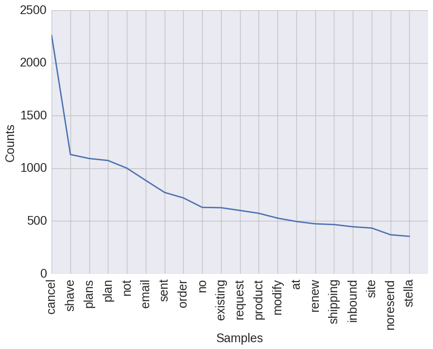

```python
tokens = []
for tweet in nltk.sent_tokenize(df['clean_tag'].to_string()):
    for word in nltk.word_tokenize(tweet):
        tokens.append(word)
#tokens[:10]
freq_dist = nltk.FreqDist(tokens)
plt.figure(num=None, figsize=(10, 7), dpi=300)
ax = plt.subplot()
for item in ([ax.title, ax.xaxis.label, ax.yaxis.label] +
             ax.get_xticklabels() + ax.get_yticklabels()):
    item.set_fontsize(18)
    del freq_dist['...']
freq_dist.plot(20)
```

## CountVectorizer:

```python
countvec = CountVectorizer(min_df = 10, max_df = 2500, stop_words = 'english')
X = countvec.fit_transform(df['clean_tag'])

count_vect_df = pd.DataFrame(X.todense(), columns=countvec.get_feature_names())
df = pd.concat([df, count_vect_df], axis=1)
df.head()
```

|  | length_mfcc | mfcc_feat_max_1 | mfcc_feat_max_2 | mfcc_feat_max_3 | mfcc_feat_max_4 | mfcc_feat_mean_1 | mfcc_feat_mean_2 | mfcc_feat_mean_3 | mfcc_feat_mean_4 | mfcc_feat_median_1 | ... | wines | winston | wismo | wobbly | work | wrong | yes | zendesk | zenvoice | zopim |
| --- | --- | --- | --- | --- | --- | --- | --- | --- | --- | --- | --- | --- | --- | --- | --- | --- | --- | --- | --- | --- | --- |
| 0 | 0.012662 | 0.013166 | 0.013514 | 0.013047 | 0.014617 | 0.012533 | 0.010936 | -0.013221 | 0.002299 | 0.012575 | ... | 0 | 0 | 0 | 0 | 0 | 0 | 0 | 0 | 0 | 0 |
| 1 | 0.010285 | 0.013512 | 0.012995 | 0.017122 | 0.015106 | 0.014554 | 0.013053 | -0.014758 | 0.010086 | 0.014934 | ... | 0 | 0 | 0 | 0 | 0 | 0 | 0 | 0 | 0 | 0 |
| 2 | 0.004971 | 0.013171 | 0.013959 | 0.013563 | 0.012443 | 0.011671 | 0.010635 | -0.009478 | 0.000347 | 0.011410 | ... | 0 | 0 | 0 | 0 | 0 | 0 | 0 | 0 | 0 | 0 |
| 3 | 0.005238 | 0.013267 | 0.013109 | 0.017767 | 0.012150 | 0.012791 | 0.015263 | -0.012415 | 0.011981 | 0.012702 | ... | 0 | 0 | 0 | 0 | 0 | 0 | 0 | 0 | 0 | 0 |
| 4 | 0.009533 | 0.012874 | 0.013845 | 0.015687 | 0.013242 | 0.013607 | 0.017079 | -0.011157 | 0.008279 | 0.013848 | ... | 0 | 0 | 0 | 0 | 0 | 0 | 0 | 0 | 0 | 0 |

5 rows × 419 columns

```python
df = df.loc[:,~df.columns.duplicated()]
df.head()
```

|  | length_mfcc | mfcc_feat_max_1 | mfcc_feat_max_2 | mfcc_feat_max_3 | mfcc_feat_max_4 | mfcc_feat_mean_1 | mfcc_feat_mean_2 | mfcc_feat_mean_3 | mfcc_feat_mean_4 | mfcc_feat_median_1 | ... | wines | winston | wismo | wobbly | work | wrong | yes | zendesk | zenvoice | zopim |
| --- | --- | --- | --- | --- | --- | --- | --- | --- | --- | --- | --- | --- | --- | --- | --- | --- | --- | --- | --- | --- | --- |
| 0 | 0.012662 | 0.013166 | 0.013514 | 0.013047 | 0.014617 | 0.012533 | 0.010936 | -0.013221 | 0.002299 | 0.012575 | ... | 0 | 0 | 0 | 0 | 0 | 0 | 0 | 0 | 0 | 0 |
| 1 | 0.010285 | 0.013512 | 0.012995 | 0.017122 | 0.015106 | 0.014554 | 0.013053 | -0.014758 | 0.010086 | 0.014934 | ... | 0 | 0 | 0 | 0 | 0 | 0 | 0 | 0 | 0 | 0 |
| 2 | 0.004971 | 0.013171 | 0.013959 | 0.013563 | 0.012443 | 0.011671 | 0.010635 | -0.009478 | 0.000347 | 0.011410 | ... | 0 | 0 | 0 | 0 | 0 | 0 | 0 | 0 | 0 | 0 |
| 3 | 0.005238 | 0.013267 | 0.013109 | 0.017767 | 0.012150 | 0.012791 | 0.015263 | -0.012415 | 0.011981 | 0.012702 | ... | 0 | 0 | 0 | 0 | 0 | 0 | 0 | 0 | 0 | 0 |
| 4 | 0.009533 | 0.012874 | 0.013845 | 0.015687 | 0.013242 | 0.013607 | 0.017079 | -0.011157 | 0.008279 | 0.013848 | ... | 0 | 0 | 0 | 0 | 0 | 0 | 0 | 0 | 0 | 0 |

5 rows × 418 columns

<a id= '4'></a>

## Makeing dataset:

Return to top

```python
columns = ['Unnamed: 0','category','gradable_id','composer_id','qa_score','tags','clean_tag','text','clean_text','time','csat_score','length_audio']
X = df.drop(columns, 1)
y = df['category']
```

```python
X.shape
```

```
(5670, 406)
```

```python
X.head()
```

|  | length_mfcc | mfcc_feat_max_1 | mfcc_feat_max_2 | mfcc_feat_max_3 | mfcc_feat_max_4 | mfcc_feat_mean_1 | mfcc_feat_mean_2 | mfcc_feat_mean_3 | mfcc_feat_mean_4 | mfcc_feat_median_1 | ... | wines | winston | wismo | wobbly | work | wrong | yes | zendesk | zenvoice | zopim |
| --- | --- | --- | --- | --- | --- | --- | --- | --- | --- | --- | --- | --- | --- | --- | --- | --- | --- | --- | --- | --- | --- |
| 0 | 0.012662 | 0.013166 | 0.013514 | 0.013047 | 0.014617 | 0.012533 | 0.010936 | -0.013221 | 0.002299 | 0.012575 | ... | 0 | 0 | 0 | 0 | 0 | 0 | 0 | 0 | 0 | 0 |
| 1 | 0.010285 | 0.013512 | 0.012995 | 0.017122 | 0.015106 | 0.014554 | 0.013053 | -0.014758 | 0.010086 | 0.014934 | ... | 0 | 0 | 0 | 0 | 0 | 0 | 0 | 0 | 0 | 0 |
| 2 | 0.004971 | 0.013171 | 0.013959 | 0.013563 | 0.012443 | 0.011671 | 0.010635 | -0.009478 | 0.000347 | 0.011410 | ... | 0 | 0 | 0 | 0 | 0 | 0 | 0 | 0 | 0 | 0 |
| 3 | 0.005238 | 0.013267 | 0.013109 | 0.017767 | 0.012150 | 0.012791 | 0.015263 | -0.012415 | 0.011981 | 0.012702 | ... | 0 | 0 | 0 | 0 | 0 | 0 | 0 | 0 | 0 | 0 |
| 4 | 0.009533 | 0.012874 | 0.013845 | 0.015687 | 0.013242 | 0.013607 | 0.017079 | -0.011157 | 0.008279 | 0.013848 | ... | 0 | 0 | 0 | 0 | 0 | 0 | 0 | 0 | 0 | 0 |

5 rows × 406 columns

<a id= '5'></a>

## Model selection:

GridSearchCV with 5 fold is used to find the best model with optimized parameters.

Return to top

```python
model = RandomForestClassifier()
n_estimators = list(range(10, 700, 100))
min_samples_split = list(range(10, 700, 100))
min_samples_leaf=list(range (1, 100, 20))
min_impurity_split=[1e-30, 1e-20, 1e-40, 1e-50, 1e-60 ]
criterion = ['entropy', 'gini']
param_grid = dict(n_estimators=n_estimators, min_samples_split = min_samples_split,
                  criterion=criterion, min_samples_leaf= min_samples_leaf, min_impurity_split= min_impurity_split
                  )

print(param_grid)

grid = GridSearchCV(model, param_grid, cv=5, scoring='roc_auc', n_jobs=-1)
grid.fit(X, y)

grid.grid_scores_
print(grid.best_score_)
print(grid.best_params_)
print(grid.best_estimator_)
rf  = grid.best_estimator_
```

```
{'min_impurity_split': [1e-30, 1e-20, 1e-40, 1e-50, 1e-60], 'n_estimators': [10, 110, 210, 310, 410, 510, 610], 'criterion': ['entropy', 'gini'], 'min_samples_leaf': [1, 21, 41, 61, 81], 'min_samples_split': [10, 110, 210, 310, 410, 510, 610]}
0.652704976165
{'min_impurity_split': 1e-50, 'n_estimators': 610, 'criterion': 'entropy', 'min_samples_leaf': 1, 'min_samples_split': 10}
RandomForestClassifier(bootstrap=True, class_weight=None, criterion='entropy',
            max_depth=None, max_features='auto', max_leaf_nodes=None,
            min_impurity_split=1e-50, min_samples_leaf=1,
            min_samples_split=10, min_weight_fraction_leaf=0.0,
            n_estimators=610, n_jobs=1, oob_score=False, random_state=None,
            verbose=0, warm_start=False)
```

```python
model = GradientBoostingClassifier()


n_estimators = list(range(100, 600, 100))
loss = ['exponential', 'deviance']
learning_rate  = [1, 0.1, 0.01]
max_depth = [3, 50, 100]
min_samples_leaf=list(range (1, 20, 18))

param_grid = dict(n_estimators=n_estimators, loss = loss,
                  learning_rate =learning_rate,
                  max_depth = max_depth,
                  min_samples_leaf = min_samples_leaf)


print(param_grid)

grid = GridSearchCV(model, param_grid, cv=5, scoring='roc_auc', n_jobs=-1)
grid.fit(X, y)

grid.grid_scores_
print(grid.best_score_)
print(grid.best_params_)
print(grid.best_estimator_)
grb  = grid.best_estimator_
```

```
{'max_depth': [3, 50, 100], 'loss': ['exponential', 'deviance'], 'min_samples_leaf': [1, 19], 'n_estimators': [100, 200, 300, 400, 500], 'learning_rate': [1, 0.1, 0.01]}
0.649686056485
{'loss': 'exponential', 'max_depth': 3, 'min_samples_leaf': 19, 'n_estimators': 300, 'learning_rate': 0.1}
GradientBoostingClassifier(criterion='friedman_mse', init=None,
              learning_rate=0.1, loss='exponential', max_depth=3,
              max_features=None, max_leaf_nodes=None,
              min_impurity_split=1e-07, min_samples_leaf=19,
              min_samples_split=2, min_weight_fraction_leaf=0.0,
              n_estimators=300, presort='auto', random_state=None,
              subsample=1.0, verbose=0, warm_start=False)
```

```python
model = LogisticRegression()


C = [10,1,0.1,0.01, 0.001]
solver = ['sag', 'newton-cg']

param_grid = dict(C = C,
                  solver = solver,
                )


print(param_grid)

grid = GridSearchCV(model, param_grid, cv=5, scoring='roc_auc',n_jobs=-1)
grid.fit(X, y)

grid.grid_scores_
lg = grid.best_estimator_
print(grid.best_score_)
print(grid.best_params_)
print(grid.best_estimator_)
lg = grid.best_estimator_
```

```
{'solver': ['sag', 'newton-cg'], 'C': [10, 1, 0.1, 0.01, 0.001]}
```

[output not shown]

```
0.64143434993
{'solver': 'sag', 'C': 1}
LogisticRegression(C=1, class_weight=None, dual=False, fit_intercept=True,
          intercept_scaling=1, max_iter=100, multi_class='ovr', n_jobs=1,
          penalty='l2', random_state=None, solver='sag', tol=0.0001,
          verbose=0, warm_start=False)
```

```python
model = KNeighborsClassifier()

n_neighbors = list(range(10, 1000, 100))
leaf_size = list(range(30, 530 , 100))
p= [1,2]
weights = ['distance', 'uniform']

param_grid = dict(n_neighbors=n_neighbors,
                  leaf_size = leaf_size,
                  p=p
                  )

print(param_grid)

grid = GridSearchCV(model, param_grid, cv=5, scoring='roc_auc', n_jobs=-1)
grid.fit(X, y)
grid.grid_scores_

grid.grid_scores_
print(grid.best_score_)
print(grid.best_params_)
print(grid.best_estimator_)
knn  = grid.best_estimator_
```

```
{'p': [1, 2], 'n_neighbors': [10, 110, 210, 310, 410, 510, 610, 710, 810, 910], 'leaf_size': [30, 130, 230, 330, 430]}
0.648160437841
{'leaf_size': 30, 'n_neighbors': 10, 'p': 2}
KNeighborsClassifier(algorithm='auto', leaf_size=30, metric='minkowski',
           metric_params=None, n_jobs=1, n_neighbors=10, p=2,
           weights='uniform')
```

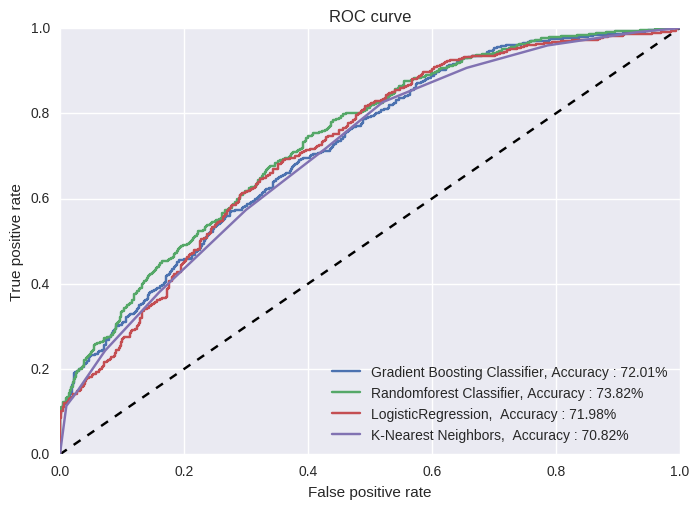

```python
seed = 7
test_size = 0.3
X_train, X_test, y_train, y_test = cross_validation.train_test_split(X, y, test_size=test_size, random_state=seed)

# The gradient boosted

grd = grb
grd.fit(X_train, y_train)

y_pred_grd = grd.predict_proba(X_test)[:, 1]
fpr_grd, tpr_grd, _ = roc_curve(y_test, y_pred_grd)

roc_score_grd = roc_auc_score(y_test, y_pred_grd)

# ----------------------------------
# The RandomForestClassifier
rf = rf

rf.fit(X_train, y_train)

y_pred_rf = rf.predict_proba(X_test)[:, 1]
fpr_rf, tpr_rf, _ = roc_curve(y_test, y_pred_rf)

roc_score_rf = roc_auc_score(y_test, y_pred_rf)


# ----------------------------------
# The LogisticRegression
lg = lg

lg.fit(X_train, y_train)

y_pred_lg = lg.predict_proba(X_test)[:, 1]
fpr_lg, tpr_lg, _ = roc_curve(y_test, y_pred_lg)

lg.fit(X_train, y_train)

y_pred_lg = lg.predict_proba(X_test)[:, 1]
fpr_lg, tpr_lg, _ = roc_curve(y_test, y_pred_lg)

roc_score_lg = roc_auc_score(y_test, y_pred_lg)
# ----------------------------------
# KNeighborsClassifier
knn = knn

knn.fit(X_train, y_train)

y_pred_knn = knn.predict_proba(X_test)[:, 1]
fpr_knn, tpr_knn, _ = roc_curve(y_test, y_pred_knn)

knn.fit(X_train, y_train)

y_pred_knn = knn.predict_proba(X_test)[:, 1]
fpr_knn, tpr_knn, _ = roc_curve(y_test, y_pred_knn)

roc_score_knn = roc_auc_score(y_test, y_pred_knn)


# ----------------------------------


plt.figure(1)
plt.plot([0, 1], [0, 1], 'k--')
plt.plot(fpr_grd, tpr_grd, label='Gradient Boosting Classifier, Accuracy : %.2f%%' % (roc_score_grd * 100.0))
plt.plot(fpr_rf, tpr_rf, label='Randomforest Classifier, Accuracy : %.2f%%' % (roc_score_rf * 100.0))
plt.plot(fpr_lg, tpr_lg, label='LogisticRegression,  Accuracy : %.2f%%' % (roc_score_lg * 100.0))
plt.plot(fpr_knn, tpr_knn, label='K-Nearest Neighbors,  Accuracy : %.2f%%' % (roc_score_knn * 100.0))
plt.xlabel('False positive rate')
plt.ylabel('True positive rate')
plt.title('ROC curve')
plt.legend(loc='best')
plt.show()
```

<a id= '6'></a>

## Feature importance:

Return to top

## Feature importance

After finding the optimal model. In the next section I’ve looked at feature importance to gain more insight.

```python
seed = 7
test_size = 0.3
X_train, X_test, y_train, y_test = cross_validation.train_test_split(X, y, test_size=test_size, random_state=seed)

rf =rf
rf.fit(X_train, y_train)

y_pred_rf = rf.predict_proba(X_test)[:, 1]
fpr_rf, tpr_rf, _ = roc_curve(y_test, y_pred_rf)

roc_score_rf = roc_auc_score(y_test, y_pred_rf)
roc_score_rf
```

```
0.73676342465185096
```

```python
headers = ["name", "score"]
values = sorted(zip(X_train.columns, rf.feature_importances_), key=lambda x: x[1] * -1)
```

```python
headers = ["name", "score"]
values = sorted(zip(X_train.columns, rf.feature_importances_), key=lambda x: x[1] * -1)

feature = pd.DataFrame.from_dict(values,)
feature.columns = ("name", "score")
feature = feature.sort(['score'],ascending = False)
feature = feature.set_index(['name'])

#feature = feature.value_counts()

iplot(feature[:10].iplot(asFigure=True,
                 kind='bar',
                 xTitle='',
                 yTitle='Score',
                 title='Feature importance' ))
```

[interactive chart not shown]

```python
data = [go.Bar(
            x=feature[:40].score,
            y=feature[:40].index,
            orientation = 'h'
)]

iplot(data, filename='horizontal-bar')
```

[interactive chart not shown]

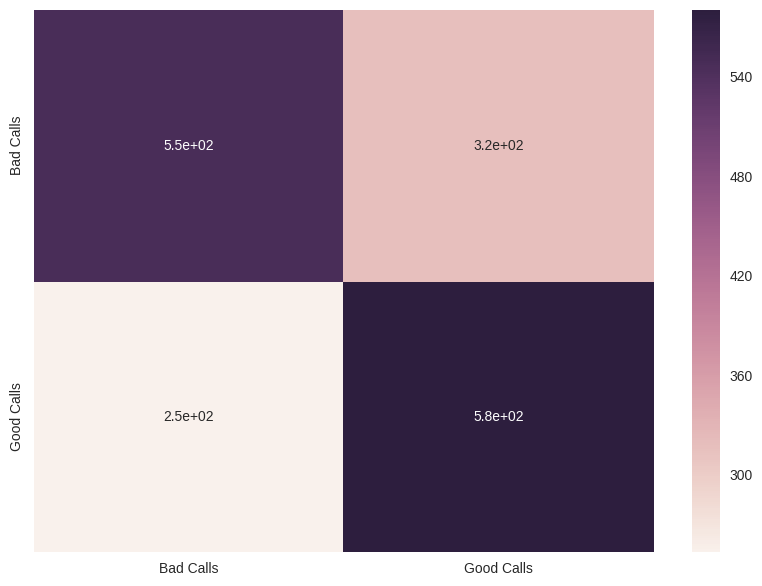

```python
%matplotlib inline
predictions = [round(value) for value in y_pred_rf]
cm =confusion_matrix(y_test, predictions)

df_cm = pd.DataFrame(cm, columns=(['Bad Calls', 'Good Calls']), index = (['Bad Calls', 'Good Calls']))
plt.figure(figsize = (10,7))
sn.heatmap(df_cm, annot=True)
```

```python
print(f1_score(y_test, predictions, average="macro"))
print(precision_score(y_test, predictions, average="macro"))
print(recall_score(y_test, predictions, average="macro"))
```

```
0.663600607403
0.664782703974
0.664301420254
```

### Gradient Boosting Classifier:

```python
seed = 7
test_size = 0.3
X_train, X_test, y_train, y_test = cross_validation.train_test_split(X, y, test_size=test_size, random_state=seed)

rf = grb

rf.fit(X_train, y_train)

y_pred_rf = rf.predict_proba(X_test)[:, 1]
fpr_rf, tpr_rf, _ = roc_curve(y_test, y_pred_rf)

roc_score_rf = roc_auc_score(y_test, y_pred_rf)
roc_score_rf
```

```
0.72011173956936014
```

```python
headers = ["name", "score"]
values = sorted(zip(X_train.columns, rf.feature_importances_), key=lambda x: x[1] * -1)

feature = pd.DataFrame.from_dict(values,)
feature.columns = ("name", "score")
feature = feature.sort(['score'],ascending = False)
feature = feature.set_index(['name'])

#feature = feature.value_counts()

iplot(feature[:40].iplot(asFigure=True,
                 kind='bar',
                 xTitle='',
                 yTitle='Score',
                 title='Feature importance' ))
```

[interactive chart not shown]

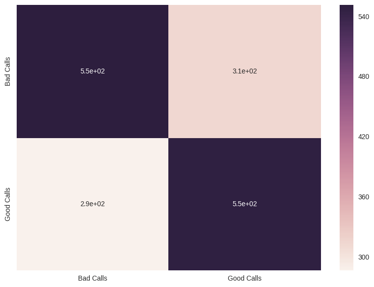

```python
predictions = [round(value) for value in y_pred_rf]
cm =confusion_matrix(y_test, predictions)

df_cm = pd.DataFrame(cm, columns=(['Bad Calls', 'Good Calls']), index = (['Bad Calls', 'Good Calls']))
plt.figure(figsize = (10,7))
sn.heatmap(df_cm, annot=True)
```

```python
print(f1_score(y_test, predictions, average="macro"))
print(precision_score(y_test, predictions, average="macro"))
print(recall_score(y_test, predictions, average="macro"))
```

```
0.646676470639
0.646828480486
0.646850410034
```